# Assignment 1 - Part B - Neural Networks with PyTorch

In this assignment, we are going to train a Neural Networks on the Japanese KMNIST dataset. It is composed of 70000 images of handwritten Hiragana characters. The target variables has 10 different classes.

Each image is of dimension 28 by 28. But we will flatten them to form a dataset composed of vectors of dimension (784, 1). The training process will be similar as for a structured dataset.

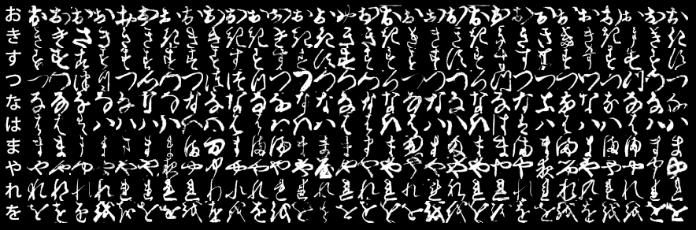

Business objective: The goal is to run at least 3 experiments and get a model that can achieve **80% accuracy with not much overfitting on this dataset.**

Business constraint: Only fully-connected and dropout layers can be used for this assignment. No other layers, such as convolution layers for instance can be used.

# 1. Import Required Packages & Device Selection

[1.1] We are going to use numpy, matplotlib and google.colab packages

```python
import numpy as np
import torch
import matplotlib.pyplot as plt
%pip install -q japanize-matplotlib
import sys
if 'google.colab' in sys.modules:
  from google.colab import drive
else:
  print("Not running on Google Colab")
```

```
Not running on Google Colab
```

[1.2] We are going to select CUDA as device of choice

```python
# I had to add this code, because my laptop does have CUDA, but it isn't supported by Torch anymore.
def get_device():
    if torch.cuda.is_available():
        # Get the compute capability of your GPU (e.g., (3, 5) for sm_35)
        capability = torch.cuda.get_device_capability(0)
        if capability[0] < 7:
            print(f"CUDA device found but compute capability {capability} is not supported. Using CPU.")
            return "cpu"
        return "cuda"
    return "cpu"

device = get_device()
device
```

```
CUDA device found but compute capability (6, 1) is not supported. Using CPU.
```

```
'cpu'
```

[1.3] Set display/presentation options so that printing 28x28 images don't break lines.

```python
torch.set_printoptions(linewidth=160)
np.set_printoptions(edgeitems=30, linewidth=160,
    formatter=dict(float=lambda x: "%.3g" % x))
```

# 2. Download Dataset

We will store the dataset into your personal Google Drive.

[2.1] Mount Google Drive

```python
if 'google.colab' in sys.modules:
  drive.mount('/content/gdrive')
```

[2.2] Create a folder called `DL_ASG_1` on your Google Drive at the root level

```python
if 'google.colab' in sys.modules:
  ! mkdir -p /content/gdrive/MyDrive/DL_ASG_1
```

[2.3] Navigate to this folder

```python
if 'google.colab' in sys.modules:
  %cd '/content/gdrive/MyDrive/DL_ASG_1'
```

[2.4] Show the list of item on the folder

```python
!ls -l *.npz
```

```
-rw-r--r-- 1 coezbek coezbek  3069285 Feb 26 14:50 kmnist-test-imgs.npz
-rw-r--r-- 1 coezbek coezbek     5304 Feb 26 14:49 kmnist-test-labels.npz
-rw-r--r-- 1 coezbek coezbek 18252235 Feb 26 14:50 kmnist-train-imgs.npz
-rw-r--r-- 1 coezbek coezbek    29700 Feb 26 14:49 kmnist-train-labels.npz
```

[2.4] Dowload the dataset files to your Google Drive if required

```python
# We use wget (without overriding to get the files)
!wget --trust-server-names --quiet --content-disposition --no-clobber "https://drive.google.com/uc?export=download&id=10l2JdpT4_D_Gw0eiJ_X_iaYwC6_FYFom"
!wget --trust-server-names --quiet --content-disposition --no-clobber "https://drive.google.com/uc?export=download&id=1PULvgUZZ6u7-2GTd0yaNPpwiU0ED_fD0"
!wget --trust-server-names --quiet --content-disposition --no-clobber "https://drive.google.com/uc?export=download&id=1gkS2LnoY5tdAuvaZNJ6kn6bsMp5uzD1B"
!wget --trust-server-names --quiet --content-disposition --no-clobber "https://drive.google.com/uc?export=download&id=1ovEOFfs-vZgYYFqXYnknAsn-DRWOgoU6"
```

[2.5] List the content of the folder and confirm files have been dowloaded properly

```python
! ls -l *.npz
```

```
-rw-r--r-- 1 coezbek coezbek  3069285 Feb 26 14:50 kmnist-test-imgs.npz
-rw-r--r-- 1 coezbek coezbek     5304 Feb 26 14:49 kmnist-test-labels.npz
-rw-r--r-- 1 coezbek coezbek 18252235 Feb 26 14:50 kmnist-train-imgs.npz
-rw-r--r-- 1 coezbek coezbek    29700 Feb 26 14:49 kmnist-train-labels.npz
```

# 3. Load Data

[3.1] Import the required modules from PyTorch

```python
# I prefer to keep the code readable and directly enter torch.nn...
```

[3.2] **DONE** Create 2 variables called `img_height` and `img_width` that will both take the value 28

```python
img_height = 28
img_width = 28
```

[3.3] Create a function that loads a .npz file using numpy and return the content of the `arr_0` key

```python
def load(f):
    return np.load(f)['arr_0']
```

[3.4] **DONE** Load the 4 files saved on your Google Drive into their respective variables: x_train, y_train, x_test and y_test

```python
x_train = load('kmnist-train-imgs.npz')
x_test  = load('kmnist-test-imgs.npz')
y_train = load('kmnist-train-labels.npz')
y_test  = load('kmnist-test-labels.npz')
```

Quickly check if the data is as expected

```python
print(x_train.shape)
print(x_test.shape)
print(y_train.shape)
print(y_test.shape)
print(x_train[0])
print(f"Label: {y_train[0]}")
```

```
(60000, 28, 28)
(10000, 28, 28)
(60000,)
(10000,)
[[  0   0   0   0   0   0   0   0  10   7 233  86   0   0  32  99   0   0   0   0   0   0   0   0   0   0   0   0]
 [  0   0   0   0   0   0   0   0   0  54 255  84   0   0   7 151  19   0   0   0   0   0   0   0   0   0   0   0]
 [  0   0   0   0   0   0   0   0   0 152 251  14   0   0  25 155  98   0   0   0   0   0   0   0   0   0   0   0]
 [  0   0   0   0   0   0   0   0 129 248 188   0   0   0  80 250 191   1  78  51   0   0   0   0   0   0   0   0]
 [  0   0   0   0   0   0   0   0  87 217  62   0   0   0  66 255 254 225 234 160   0   0   0   0   0   0   0   0]
 [  0   0   0   0   0   0   0   0   0   2   0   0   0   4  93 247 244 184  95 132   0   0   0   0   0   0   0   0]
 [  0   0   0   0   0   0   0   0   0   0   0   0  74 130 136 213 112 131   0   0   0   0   0   0   0   0   0   0]
 [  0   0   0   0   0   0   0   0   0   0   0   0 147  78  54 188 120  83   0   0   0   0   0   0   0   0   0   0]
 [  0   0   0   0   0   0   0   0   0   0   0   0 109 255 249 217 131 119   0   0   0   0   0   0   0   0   0   0]
 [  0   0   0   0   0   0   0   0   0   0   0   0  30 247 145 241 187 163   0   0   0   0   0   0   0   0   0   0]
 [  0   0   0   0   0   0   0   0   0   0   0   0 133  91   7 245 255 151   0   0   0   0   0   0   0   0   0   0]
 [  0   0   0   0   0   0   0   0   0   0   0   0 128 128  20 253 255 102   0   0   0   0   0   0   0   0   0   0]
 [  0   0   0   0   0   0   0   0   0   0   0   0  95 224  20 254 255  63   0   0   0   0   0   0   0   0   0   0]
 [  0   0   0   0   0   0   0   0   0   0   0   0 112 159  64 254 223   9   0   0   0   0   0   0   0   0   0   0]
 [  0   0   0   0   0   0   0   0   0   0   0   1 211 234 253 255 107   0   0   0   0   0   0   0   0   0   0   0]
 [  0   0   0   0   0   0   0   0   0   0   0 123 254 194 244 177   1   0   0   0   0   0   0   0   0   0   0   0]
 [  0   0   0   0   0   0   0   0   0  35 173 207 170 103  84  15   0   0   0   0   0   0   0   0   0   0   0   0]
 [  0   0   0   0   0   0   0   0   2 169  43   0   0   0   0   0   0   0   0   0   0   0   0   0   0   0   0   0]
 [  0   0   0   0   0   0   0   0  81  72   0   0   0   0   0   0   0   0   0   0   0   0   0   0   0   0   0   0]
 [  0   0   0   0   0   0   0   0 134  83   0   0   0   0   0   0   0   0   0   0   0   0   0   0   0   0   0   0]
 [  0   0   0   0   0   0   0   0 136 193  16   0   0   0  16   2  48  37  14   0   0   0   0   0   0   0   0   0]
 [  0   0   0   0   0   0   0   0  57 255 205 116  41 184 243 111 240 253 249  78   0   0   0   0   0   0   0   0]
 [  0   0   0   0   0   0   0   0   1 190 255 250  74  97 228 192 228 255 250  97   0   0   0   0   0   0   0   0]
 [  0   0   0   0   0   0   0   0   0   4  73  75  30   0  38 203 255 167  37   0   0   0   0   0   0   0   0   0]
 [  0   0   0   0   0   0   0   0   0   0   0   0   0   4 210 206 112   1   0   0   0   0   0   0   0   0   0   0]
 [  0   0   0   0   0   0   0   0   0   0   0   0  40  69  78   7   0   0   0   0   0   0   0   0   0   0   0   0]
 [  0   0   0   0   0   0   0   0   0   0   0  67 124   0   0   0   0   0   0   0   0   0   0   0   0   0   0   0]
 [  0   0   0   0   0   0   0   0   0   0  74 157   9   0   0   0   0   0   0   0   0   0   0   0   0   0   0   0]]
Label: 8
```

[3.5] **DONE** Using matplotlib display the first image from the train set and its target value

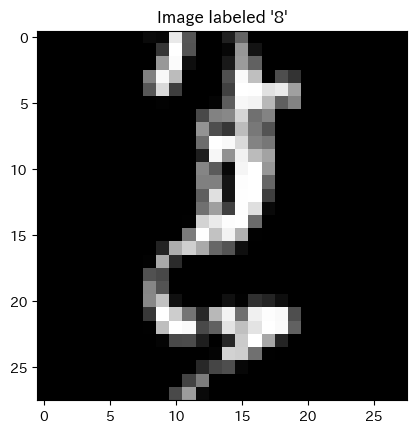

```python
plt.imshow(x_train[0], cmap='gray')
plt.title(f"Image labeled '{y_train[0]}'")
plt.show()
```

# 4. Prepare Data

[4.1] **DONE** Reshape the images from the training and testing set to have the channel dimension last. The dimensions should be: (row_number, height, width, channel)

```python
# I didn't follow this instruction, because the training code we learned in the exercises requires the data in a single dimensions. Maybe the instruction is outdated?
x_train = torch.tensor(x_train).reshape(x_train.shape[0], -1)
x_test = torch.tensor(x_test).reshape(x_test.shape[0], -1)
print(x_train.shape)
```

```
torch.Size([60000, 784])
```

[4.2] **DONE** Cast `x_train` and `x_test` into `float32` decimals

```python
x_train = x_train.to(dtype=torch.float32)
x_test = x_test.to(dtype=torch.float32)
```

[4.3] **DONE** Standardise the images of the training and testing sets. Originally each image contains pixels with value ranging from 0 to 255. after standardisation, the new value range should be from 0 to 1.

```python
x_train = x_train / 255.0
x_test = x_test / 255.0
```

```python
# Make sure we didn't mess up
assert ((x_train >= 0.0) & (x_train <= 1.0)).all()
assert ((x_test >= 0.0) & (x_test <= 1.0)).all()
```

[4.4] **DONE** Create a variable called `num_classes` that will take the value 10 which corresponds to the number of classes for the target variable

```python
num_classes = len(np.unique(y_train))
print(f"How many different labels are in y_train? => {np.unique(y_train)} = i.e. {num_classes} different labels")
```

```
How many different labels are in y_train? => [0 1 2 3 4 5 6 7 8 9] = i.e. 10 different labels
```

[4.5] **DONE** Convert the target variable for the training and testing sets to a binary class matrix of dimension (rows, num_classes).

For example:

- class 0 will become [1, 0, 0, 0, 0, 0, 0, 0, 0, 0]
- class 1 will become [0, 1, 0, 0, 0, 0, 0, 0, 0, 0]
- class 5 will become [0, 0, 0, 0, 0, 1, 0, 0, 0, 0]
- class 9 will become [0, 0, 0, 0, 0, 0, 0, 0, 0, 1]

```python
def to_binary_class_matrix(x):
  x = torch.tensor(x, dtype=torch.long) # Must convert, otherwise it seems that torch believes we want to apply a binary mask
  _x = torch.zeros(x.shape[0], num_classes)
  _x[torch.arange(x.shape[0]), x] = 1 # Reading more on it, torch.nn.functional.one_hot might have been the best choice here
  return _x

y_train_cm = to_binary_class_matrix(y_train)
y_test_cm = to_binary_class_matrix(y_test)
print(y_train_cm[:5])
```

```
tensor([[0., 0., 0., 0., 0., 0., 0., 0., 1., 0.],
        [0., 0., 0., 0., 0., 0., 0., 1., 0., 0.],
        [1., 0., 0., 0., 0., 0., 0., 0., 0., 0.],
        [0., 1., 0., 0., 0., 0., 0., 0., 0., 0.],
        [0., 0., 0., 0., 1., 0., 0., 0., 0., 0.]])
```

# 5. Define Neural Networks Architecure

[5.1] Set the seed in PyTorch for reproducing results

```python
torch.manual_seed(42)
```

```
<torch._C.Generator at 0x7890c21c8510>
```

[5.2] **DONE** Define the architecture of your Neural Networks and save it into a variable called `model`

```python
input_size = 28*28

simple_model = torch.nn.Sequential(
  torch.nn.Linear(input_size, 512),
  torch.nn.ReLU(),
  torch.nn.Linear(512, num_classes)
).to(device)
```

[5.2] **DONE** Print the summary of your model

```python
simple_model
```

```
Sequential(
  (0): Linear(in_features=784, out_features=512, bias=True)
  (1): ReLU()
  (2): Linear(in_features=512, out_features=10, bias=True)
)
```

# 6. Train Neural Networks

[6.1] **DONE** Create 2 variables called `batch_size` and `epochs` that will respectively take the values 128 and 500

```python
batch_size = 1024 # A batch size of 1024 does not have any negative effect on training but significantly speeds up GPU computation.
epochs = 500
```

[6.2] **DONE** Compile your model with the appropriate loss function, the optimiser of your choice and the accuracy metric

```python
loss_function = torch.nn.CrossEntropyLoss() # Categorical cross entropy loss for multi-class categorization task
optim = torch.optim.AdamW(params=simple_model.parameters(), lr=0.001) # Use weighted Adam optimizer

train_dataset = torch.utils.data.TensorDataset(x_train, y_train_cm)
test_dataset = torch.utils.data.TensorDataset(x_test, y_test_cm)

dataloader_train = torch.utils.data.DataLoader(train_dataset, batch_size = batch_size, shuffle=True)
dataloader_test = torch.utils.data.DataLoader(test_dataset, batch_size = batch_size, shuffle=True)
```

[6.2b] Define plotting function for plotting losses and accuracy

```python
from IPython.display import clear_output
import matplotlib.ticker as mticker

def do_loss_plot(training_history):
    """
    Pass an array of hashes representing the training runs to generate a plot of loss+accuracy.
    Each hash is a single training run and needs epoch, n_epochs, training_loss, testing_loss and accuracy.

    Acknowledgement: I needed help from Gemini to get the simultaneous axis right.
    """

    clear_output(wait=True)

    _, ax1 = plt.subplots(figsize=(10, 6))

    n_epochs = training_history[0]['n_epochs']
    i_epochs = max([d["epoch"] for d in training_history])
    epochs_range =[d["epoch"]+1 for d in training_history]

    # Left axis for loss
    color = 'tab:red'
    ax1.set_xlabel('Epochs')
    ax1.set_ylabel('Loss', color=color, fontsize=12)
    l1 = ax1.plot(epochs_range, [d["training_loss"] for d in training_history], label='Train Loss', color=color, linestyle='-', alpha=0.7)
    l2 = ax1.plot(epochs_range, [d["testing_loss"] for d in training_history], label='Test Loss', color=color, linestyle='--', linewidth=2)
    ax1.tick_params(axis='y', labelcolor=color)
    ax1.set_ylim(0, max([d["testing_loss"] for d in training_history])) # Left axis from 0.0 to max

    # Right axis for accuracy
    ax2 = ax1.twinx()
    color = 'tab:blue'
    ax2.set_ylabel('Accuracy', color=color, fontsize=12)
    l3 = ax2.plot(epochs_range, [d["accuracy"] for d in training_history], label='Test Accuracy', color=color, linewidth=3)
    ax2.tick_params(axis='y', labelcolor=color)
    ax2.set_ylim(0.5, 1.00) # 0-100% scale

    # major at 0.1, minor at 0.05
    ax2.yaxis.set_major_locator(mticker.MultipleLocator(0.05))
    ax2.yaxis.set_minor_locator(mticker.MultipleLocator(0.01))
    ax1.grid(False)  # disable left axis grid
    ax2.set_axisbelow(True)  # grid behind data
    ax2.grid(True, which="major", axis="y", alpha=0.3)
    ax2.grid(True, which="minor", axis="y", alpha=0.15)

    lines = l1 + l2 + l3 # Combine legends from both axes
    labels = [l.get_label() for l in lines]
    ax1.legend(lines, labels, loc='center right')

    plt.title(f"Training Progress - Epoch {i_epochs+1:d}/{n_epochs}")
    plt.tight_layout()
    plt.show()
```

[6.3] **DONE** Train your model using the number of epochs defined. Calculate the total loss and save it to a variable called total_loss.

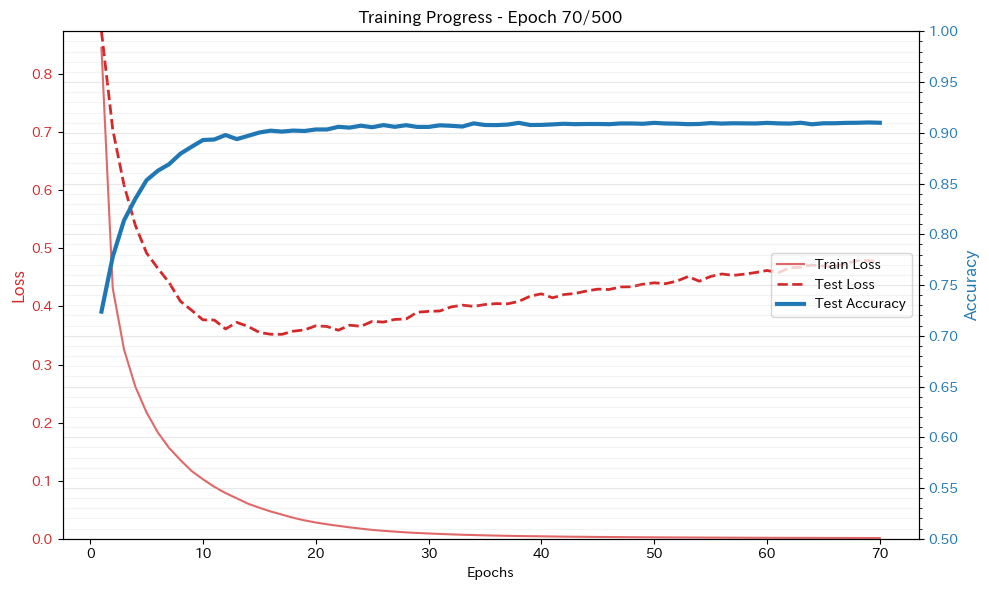

```
Epoch   1: 'Training Loss' 0.8455 - Testing Loss: 0.8738 = 72.4% accuracy
Epoch   8: 'Training Loss' 0.1355 - Testing Loss: 0.4090 = 87.9% accuracy
Epoch  16: 'Training Loss' 0.0469 - Testing Loss: 0.3521 = 90.2% accuracy
Epoch  24: 'Training Loss' 0.0173 - Testing Loss: 0.3658 = 90.7% accuracy
Epoch  31: 'Training Loss' 0.0082 - Testing Loss: 0.3922 = 90.7% accuracy
Epoch  39: 'Training Loss' 0.0044 - Testing Loss: 0.4177 = 90.8% accuracy
Epoch  47: 'Training Loss' 0.0028 - Testing Loss: 0.4336 = 90.9% accuracy
Epoch  54: 'Training Loss' 0.0020 - Testing Loss: 0.4435 = 90.9% accuracy
Epoch  62: 'Training Loss' 0.0015 - Testing Loss: 0.4666 = 90.9% accuracy
Epoch  70: 'Training Loss' 0.0012 - Testing Loss: 0.4776 = 91.0% accuracy
Stopping because loss is < 0.001
```

```python
import math

def train_one_epoch(dataloader, model, data_augmentation, optimizer, loss_function, device):
    total_loss = 0

    # Set the model to training model
    model.train()
    for data, target in dataloader:

        # Move tensors to the same device as the model
        data = data.to(device)
        target = target.to(device)

        # CÖ: I added a data_augmentation function to scale/rotate/shift the images to increase the available data for the model
        if data_augmentation:
            data = data_augmentation(data)

        # Reset the gradients
        optimizer.zero_grad()

        # Forward Propagation to get predicted outcome
        outputs = model(data)

        # Compute the loss
        loss = loss_function(outputs, target)

        # Compute gradients
        loss.backward()

        # Update the weights
        optimizer.step()

        total_loss += loss.item()

    return total_loss / len(dataloader)

def test_one_epoch(dataloader, model, loss_func, device):

    testing_loss = 0.0
    correct_predictions = 0

    targets = []
    predictions = []
    images = []

    # Set the model to evaluation mode
    model.eval()
    with torch.no_grad():
        for data, target in dataloader:

            # Move tensors to the same device as the model
            data = data.to(device)
            target = target.to(device)

            # Forward Propagation to get predicted outcome
            outputs = model(data)

            # Store for confusion matrix
            targets.extend(target.argmax(dim=1).cpu().tolist())
            predictions.extend(outputs.argmax(dim=1).cpu().tolist())
            images.extend(data.cpu().numpy())

            # Compute the loss
            loss = loss_func(outputs, target)

            # Debug Prints:
            # print(outputs[0])
            # print(target[0])
            # print(outputs.argmax(dim=1))
            # print(target.argmax(dim=1))

            # Check if we predicted correctly
            correct_predictions += (outputs.argmax(dim=1) == target.argmax(dim=1)).type(torch.float32).sum().item()

            testing_loss += loss.item()

    return testing_loss / len(dataloader), correct_predictions / len(dataloader.dataset), targets, predictions, images

def run_experiment(model, aug_layer, optim):
    progress_info = []
    best_loss = math.inf
    epochs_since_best = 0

    for i in range(epochs):
        total_loss = train_one_epoch(dataloader_train, model, aug_layer, optim, loss_function, device)
        testing_loss, accuracy, _, _, _= test_one_epoch(dataloader_test, model, loss_function, device)

        # Stop if we haven't improved
        if total_loss < best_loss * 0.999:
            epochs_since_best = 0
            best_loss = total_loss
        else:
            epochs_since_best += 1
            if epochs_since_best >= 20:
                print(f"Stopped training after {i} epochs, because loss didn't decrease by 0.1% or more within 20 epochs")
                break

        if total_loss < 0.001:
            print(f"Stopping because loss is < 0.001")
            break

        progress = {
            'training_loss': total_loss,
            'testing_loss': testing_loss,
            'accuracy': accuracy,
            'epoch': i,
            'n_epochs': epochs,
        }

        yield progress

        progress_info.append(progress)

        # Print every 10th epoch
        if (i+1) % 10 == 0:
            do_loss_plot(progress_info)
            for i in torch.linspace(0, len(progress_info) - 1, steps = min(len(progress_info), 10), dtype=torch.int):
                print(f"Epoch {i+1:>3d}: 'Training Loss' {progress_info[i]['training_loss']:.4f} - Testing Loss: {progress_info[i]['testing_loss']:.4f} = {progress_info[i]['accuracy'] * 100:.1f}% accuracy")

# First, we do not use data augmentation, just the simple model from above
progress_info = []
for progress in run_experiment(simple_model, None, optim):
    progress_info.append(progress)
```

[6.4] **DONE** Test your model. Initiate the model.eval() along with torch.no_grad() to turn off the gradients.

```python
# Also see above [6.3], after each training epoch
testing_loss, accuracy, latest_targets, latest_predictions, latest_images = test_one_epoch(dataloader_test, simple_model, loss_function, device)
print(f"Epoch {progress_info[-1]['epoch']:>3d}: Testing Loss: {testing_loss:.4f} = {accuracy * 100:.1f}% accuracy")
```

```
Epoch  76: Testing Loss: 0.4911 = 90.9% accuracy
```

# 7. Analyse Results

[7.1] **DONE** Display the performance of your model on the training and testing sets

```python
training_loss, training_accuracy, _, _, _ = test_one_epoch(dataloader_train, simple_model, loss_function, device)

print(f"Model performance after {progress_info[-1]['epoch']:>3d} epochs:")
print(f"  Accuracy on training set: {training_accuracy * 100:.1f}% accuracy (loss={training_loss:.4f})")
print(f"  Accuracy on testing  set: {accuracy * 100:.1f}% accuracy (loss={testing_loss:.4f})")
```

```
Model performance after  76 epochs:
  Accuracy on training set: 100.0% accuracy (loss=0.0010)
  Accuracy on testing  set: 90.9% accuracy (loss=0.4911)
```

[7.2] **DONE** Plot the learning curve of your model

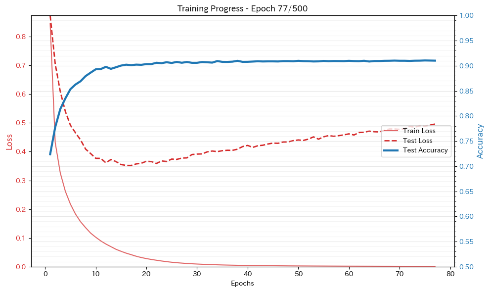

```python
do_loss_plot(progress_info)
```

[7.3] **DONE** Display the confusion matrix on the testing set predictions

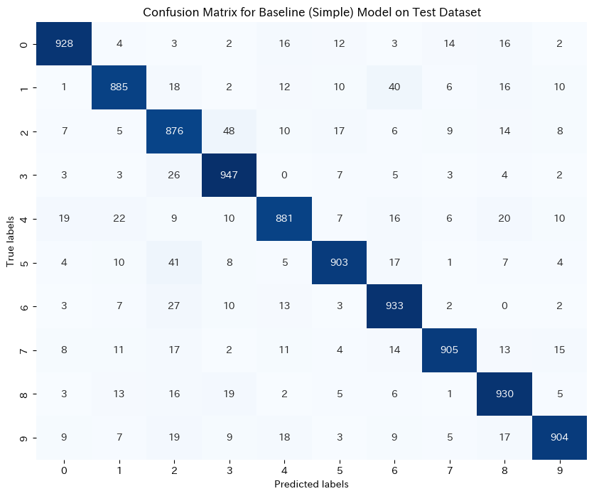

```python
import matplotlib.pyplot as plt
import seaborn #.heatmap
import sklearn.metrics #.confusion_matrix

def plot_confusion_matrix(true_labels, predicted_labels, model_title):
  # Adapted from exercise 2 of lesson 2 of UTS Deep Learning Autumn 2026

  conf_matrix = sklearn.metrics.confusion_matrix(true_labels, predicted_labels)

  # Plotting the confusion matrix
  plt.figure(figsize=(10, 8))
  seaborn.heatmap(conf_matrix, annot=True, fmt='d', cmap='Blues', cbar=False)
  plt.xlabel('Predicted labels')
  plt.ylabel('True labels')
  plt.title(f"Confusion Matrix for {model_title} on Test Dataset")
  plt.show()

plot_confusion_matrix(latest_targets, latest_predictions, "Baseline (Simple) Model")
```

[7.4] Let's examine one misprediction example in the cell with the most mispredictions

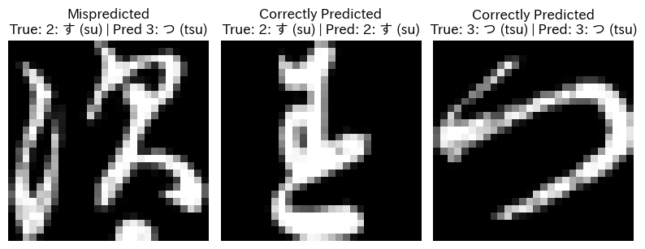

```python
# This code was created with support from Gemini Pro 3.1 to get Japanese character printing right and matplotlib parameters
class_map = [
  "0: お (o)",
  "1: き (ki)",
  "2: す (su)",
  "3: つ (tsu)",
  "4: な (na)",
  "5: は (ha)",
  "6: ま (ma)",
  "7: や (ya)",
  "8: れ (re)",
  "9: を (wo)",
]
import japanize_matplotlib # To enable japanese character support in matplotlib

# Convert lists to numpy arrays so we can easily filter them
targets_arr = np.array(latest_targets)
preds_arr = np.array(latest_predictions)
images_arr = np.array(latest_images)

conf_matrix = sklearn.metrics.confusion_matrix(latest_targets, latest_predictions)
np.fill_diagonal(conf_matrix, 0)
max_idx = np.argmax(conf_matrix)
true_label, pred_label = np.unravel_index(max_idx, conf_matrix.shape)

# the following example assumes true label is 2 and predicted label was 4

# 1. Find indices where true label is 2 but it was predicted as 4
mispredicted_mask = (targets_arr == true_label) & (preds_arr == pred_label)
mispredicted_indices = np.where(mispredicted_mask)[0]

# 2. Find indices where true label is 2 and it was correctly predicted as 2
correct_2_mask = (targets_arr == true_label) & (preds_arr == true_label)
correct_2_indices = np.where(correct_2_mask)[0]

# Find indices where true label is 4 and it was correctly predicted as 4
correct_4_mask = (targets_arr == pred_label) & (preds_arr == pred_label)
correct_4_indices = np.where(correct_4_mask)[0]

if len(mispredicted_indices) > 0 and len(correct_2_indices) > 0 and len(correct_4_indices) > 0:

    idx_mispredicted = np.random.choice(mispredicted_indices)
    idx_correct = np.random.choice(correct_2_indices)
    idx_correct4 = np.random.choice(correct_4_indices)

    # Extract the images and reshape them from (784,) back to (28, 28)
    img_mispredicted = images_arr[idx_mispredicted].reshape(28, 28)
    img_correct = images_arr[idx_correct].reshape(28, 28)
    img_correct4 = images_arr[idx_correct4].reshape(28, 28)

    # Plot them side by side
    fig, axes = plt.subplots(1, 3, figsize=(8, 4))

    axes[0].imshow(img_mispredicted, cmap='gray')
    axes[0].set_title(f"Mispredicted\nTrue: {class_map[true_label]} | Pred {class_map[pred_label]}")
    axes[0].axis('off')

    axes[1].imshow(img_correct, cmap='gray')
    axes[1].set_title(f"Correctly Predicted\nTrue: {class_map[true_label]} | Pred: {class_map[true_label]}")
    axes[1].axis('off')

    axes[2].imshow(img_correct4, cmap='gray')
    axes[2].set_title(f"Correctly Predicted\nTrue: {class_map[pred_label]} | Pred: {class_map[pred_label]}")
    axes[2].axis('off')

    plt.tight_layout()
    plt.show()
else:
    print("Could not find examples of a 2 mispredicted as a 4.")
```

# 8 Experimenting to improve the model

It is thus appropriate to use methods to prevent overfitting such as:

- Using data augmentation to increase the data versatility which also prevents learning static patterns
- Using dropouts to reduce dependence on individual neurons for classification

## 8.1 Data Augmentation

For image data as our KMNIST samples, we have the option to use simple image transformations such as rotating, scaling, transposing the image as well as changing the gray scale colors. These augmentation prevent that the neural network just learns to focus on individual pixel combinations present in the images.

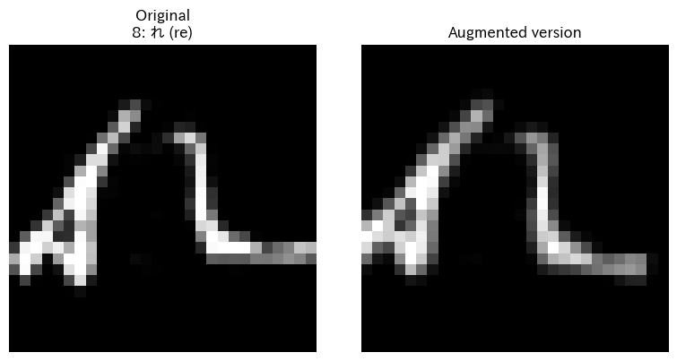

```python
from torchvision import transforms

aug_layer = torch.nn.Sequential(
    torch.nn.Unflatten(1, (1, 28, 28)), # Need to shape to match the image dimensions again
    transforms.RandomAffine(degrees=10, translate=(3.0/28.0, 3.0/28.0), scale=(0.9, 1.1), interpolation=transforms.InterpolationMode.BILINEAR), # scale and translate
    transforms.ColorJitter(brightness=0.3, contrast=0.1), # increase/decrease brightness and contrast by 30%/10%
    torch.nn.Flatten(1, -1) # go back to 28*28 tensors in the last dimension
).to(device)

def plot_augmented_sample(augmentation_layer, dataset):

    img_tensor, label_tensor = dataset[np.random.randint(len(dataset))]

    label_idx = label_tensor.argmax().item()
    label_name = class_map[label_idx]

    input_batch = img_tensor.unsqueeze(0).to(device)

    # 3. Setup the plot
    fig, axes = plt.subplots(1, 2, figsize=(8, 4))

    original_img = img_tensor.reshape(28, 28).numpy()

    axes[0].imshow(original_img, cmap='gray')
    axes[0].set_title(f"Original\n{label_name}")
    axes[0].axis('off')

    aug_output = augmentation_layer(input_batch)

    aug_img = aug_output.cpu().reshape(28, 28).numpy()

    axes[1].imshow(aug_img, cmap='gray')
    axes[1].set_title(f"Augmented version")
    axes[1].axis('off')

    plt.tight_layout()
    plt.show()

plot_augmented_sample(aug_layer, train_dataset)

# We apply the augmentation in 90% of cases only, so that the original image characteristics are also trained.
aug_layer = transforms.RandomApply(aug_layer, p=0.9)
```

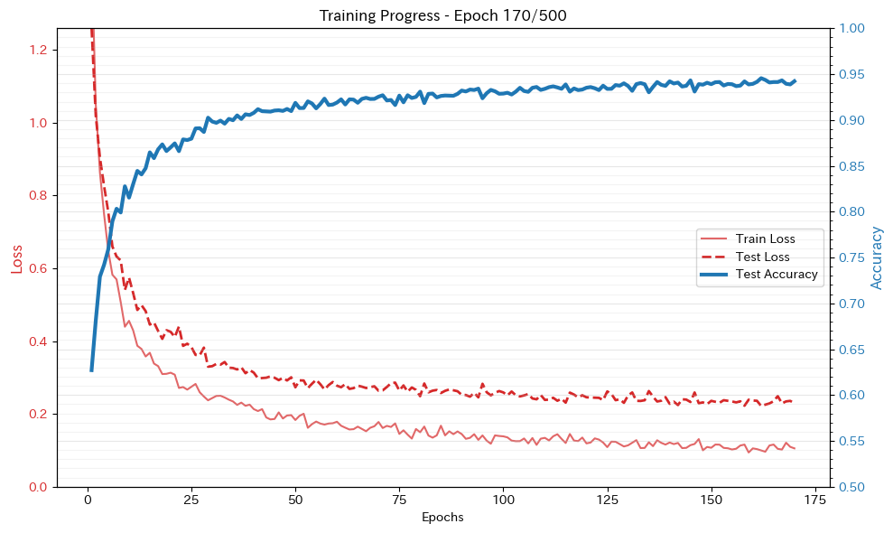

```
Epoch   1: 'Training Loss' 1.4664 - Testing Loss: 1.2597 = 62.7% accuracy
Epoch  19: 'Training Loss' 0.3101 - Testing Loss: 0.4300 = 86.6% accuracy
Epoch  38: 'Training Loss' 0.2222 - Testing Loss: 0.3118 = 90.6% accuracy
Epoch  57: 'Training Loss' 0.1707 - Testing Loss: 0.2671 = 92.3% accuracy
Epoch  76: 'Training Loss' 0.1549 - Testing Loss: 0.2783 = 91.9% accuracy
Epoch  94: 'Training Loss' 0.1286 - Testing Loss: 0.2454 = 93.4% accuracy
Epoch 113: 'Training Loss' 0.1442 - Testing Loss: 0.2361 = 93.5% accuracy
Epoch 132: 'Training Loss' 0.1279 - Testing Loss: 0.2359 = 93.9% accuracy
Epoch 151: 'Training Loss' 0.1158 - Testing Loss: 0.2333 = 94.1% accuracy
Epoch 170: 'Training Loss' 0.1053 - Testing Loss: 0.2292 = 94.2% accuracy
Stopped training after 178 epochs, because loss didn't decrease by 0.1% or more within 20 epochs
```

```python
model_augmented = torch.nn.Sequential(
  torch.nn.Linear(input_size, 512),
  torch.nn.ReLU(),
  torch.nn.Linear(512, num_classes)
).to(device)

optim = torch.optim.AdamW(params=model_augmented.parameters(), lr=0.001) # Use weighted Adam optimizer

progress_info_augmented = []
for progress in run_experiment(model_augmented, aug_layer, optim):
    progress_info_augmented.append(progress)
```

We can observe that accuracy is improved over the baseline model, but overfitting still a major issue. Due to the randomness of the augmentation being applied, the training loss is substantially more jittery.

## 8.2 Using Dropout

The wide gap between training and test accuracy indicates that the model is still overfitting on data. As a third experiment, I added a dropout of 0.2 (20%) to the first layer.

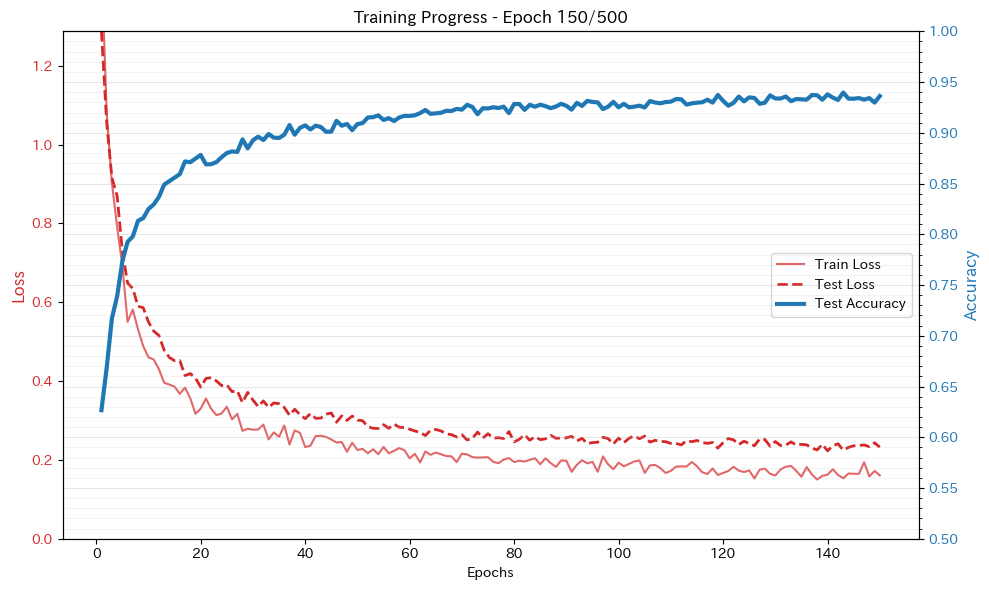

```
Epoch   1: 'Training Loss' 1.4724 - Testing Loss: 1.2876 = 62.7% accuracy
Epoch  17: 'Training Loss' 0.3838 - Testing Loss: 0.4139 = 87.2% accuracy
Epoch  34: 'Training Loss' 0.2698 - Testing Loss: 0.3445 = 89.5% accuracy
Epoch  50: 'Training Loss' 0.2253 - Testing Loss: 0.3011 = 90.9% accuracy
Epoch  67: 'Training Loss' 0.2098 - Testing Loss: 0.2662 = 92.2% accuracy
Epoch  83: 'Training Loss' 0.2000 - Testing Loss: 0.2499 = 92.8% accuracy
Epoch 100: 'Training Loss' 0.1932 - Testing Loss: 0.2554 = 92.5% accuracy
Epoch 116: 'Training Loss' 0.1686 - Testing Loss: 0.2442 = 93.0% accuracy
Epoch 133: 'Training Loss' 0.1846 - Testing Loss: 0.2457 = 93.1% accuracy
Epoch 150: 'Training Loss' 0.1607 - Testing Loss: 0.2324 = 93.6% accuracy
Stopped training after 157 epochs, because loss didn't decrease by 0.1% or more within 20 epochs
```

```python
model_dropout = torch.nn.Sequential(
  torch.nn.Linear(input_size, 512),
  torch.nn.ReLU(),
  torch.nn.Dropout(0.2),
  torch.nn.Linear(512, num_classes)
).to(device)

optim = torch.optim.AdamW(params=model_dropout.parameters(), lr=0.001) # Use weighted Adam optimizer

progress_info_dropout = []
for progress in run_experiment(model_dropout, aug_layer, optim):
    progress_info_dropout.append(progress)
```

Learning speed was slower than the previous attempt and thus the model was stopped earlier and could not achieve the same accuracies. The gap between training and testing loss is reduced, which indicates that the dropout is working as intended despite the reduced speed of learning.

## 8.3 Using a deeper network

So far the network employed was very shallow. Despite having 768 * 512 + 512 * 10 parameters (~400,000), this might not be enough to really learn the complex shapes. As a last experiment, we thus add 2 additional hidden layers of 512 neurons each.

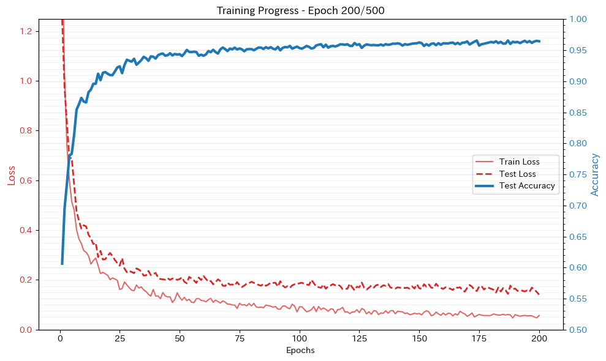

```
Epoch   1: 'Training Loss' 1.5193 - Testing Loss: 1.2481 = 60.6% accuracy
Epoch  23: 'Training Loss' 0.2036 - Testing Loss: 0.2799 = 91.6% accuracy
Epoch  45: 'Training Loss' 0.1313 - Testing Loss: 0.2071 = 94.2% accuracy
Epoch  67: 'Training Loss' 0.1067 - Testing Loss: 0.1953 = 95.1% accuracy
Epoch  89: 'Training Loss' 0.0904 - Testing Loss: 0.1880 = 95.2% accuracy
Epoch 111: 'Training Loss' 0.0818 - Testing Loss: 0.1645 = 95.9% accuracy
Epoch 133: 'Training Loss' 0.0605 - Testing Loss: 0.1808 = 95.8% accuracy
Epoch 155: 'Training Loss' 0.0560 - Testing Loss: 0.1686 = 96.0% accuracy
Epoch 177: 'Training Loss' 0.0566 - Testing Loss: 0.1612 = 96.0% accuracy
Epoch 200: 'Training Loss' 0.0568 - Testing Loss: 0.1407 = 96.4% accuracy
Stopped training after 208 epochs, because loss didn't decrease by 0.1% or more within 20 epochs
```

```python
model_deep = torch.nn.Sequential(
  torch.nn.Linear(input_size, 512),
  torch.nn.ReLU(),
  torch.nn.Dropout(0.2),
  torch.nn.Linear(512, 512),
  torch.nn.ReLU(),
  torch.nn.Linear(512, 512),
  torch.nn.ReLU(),
  torch.nn.Linear(512, num_classes)
).to(device)

optim = torch.optim.AdamW(params=model_deep.parameters(), lr=0.001) # Use weighted Adam optimizer

progress_info_dropout = []
for progress in run_experiment(model_deep, aug_layer, optim):
    progress_info_dropout.append(progress)
```

### 8.3.1 Evaluate the confusion matrix for the final experiment (`model_deep`)

```
Epoch 500: Testing Loss: 0.1586 = 96.2% accuracy
```

[figure not shown]

```python
testing_loss, accuracy, latest_targets, latest_predictions, latest_images = test_one_epoch(dataloader_test, model_deep, loss_function, device)
print(f"Epoch {epochs:>3d}: Testing Loss: {testing_loss:.4f} = {accuracy * 100:.1f}% accuracy")
plot_confusion_matrix(latest_targets, latest_predictions, "#3 Deep Model")
```

# 9 Other experiments

# 9.1 Does it make a difference to use Adam over AdamW?

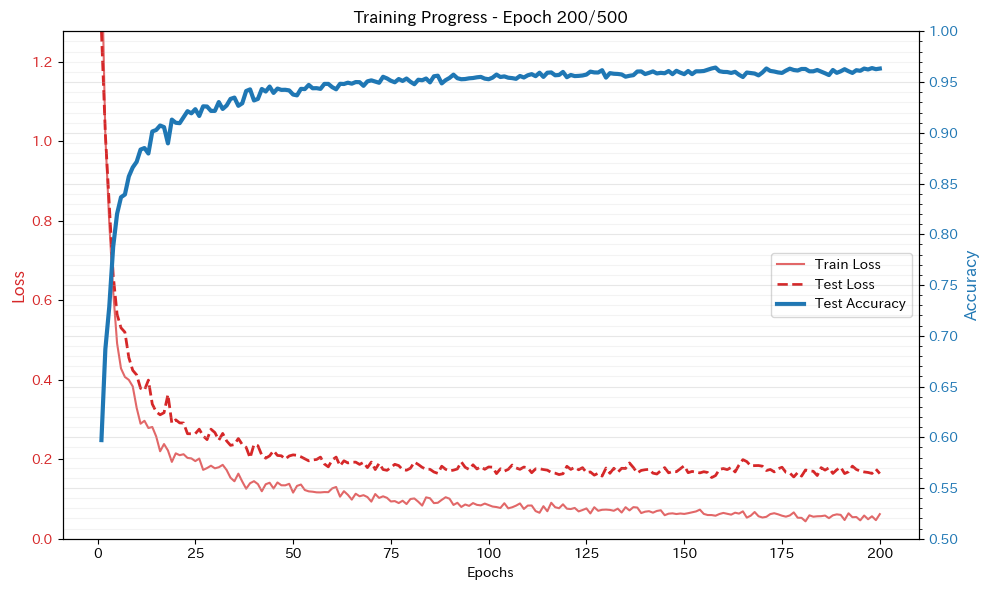

```
Epoch   1: 'Training Loss' 1.4884 - Testing Loss: 1.2764 = 59.7% accuracy
Epoch  23: 'Training Loss' 0.2033 - Testing Loss: 0.2642 = 92.1% accuracy
Epoch  45: 'Training Loss' 0.1264 - Testing Loss: 0.2214 = 93.9% accuracy
Epoch  67: 'Training Loss' 0.1068 - Testing Loss: 0.1870 = 95.0% accuracy
Epoch  89: 'Training Loss' 0.1044 - Testing Loss: 0.1746 = 95.2% accuracy
Epoch 111: 'Training Loss' 0.0835 - Testing Loss: 0.1661 = 95.8% accuracy
Epoch 133: 'Training Loss' 0.0756 - Testing Loss: 0.1672 = 95.8% accuracy
Epoch 155: 'Training Loss' 0.0624 - Testing Loss: 0.1685 = 96.1% accuracy
Epoch 177: 'Training Loss' 0.0585 - Testing Loss: 0.1653 = 96.3% accuracy
Epoch 200: 'Training Loss' 0.0619 - Testing Loss: 0.1638 = 96.3% accuracy
Stopped training after 200 epochs, because loss didn't decrease by 0.1% or more within 20 epochs
```

```python
model_adam = torch.nn.Sequential(
  torch.nn.Linear(input_size, 512),
  torch.nn.ReLU(),
  torch.nn.Dropout(0.2),
  torch.nn.Linear(512, 512),
  torch.nn.ReLU(),
  torch.nn.Linear(512, 512),
  torch.nn.ReLU(),
  torch.nn.Linear(512, num_classes)
).to(device)


optim = torch.optim.Adam(params=model_adam.parameters(), lr=0.001)

batch_size = 128

progress_info_dropout = []
for progress in run_experiment(model_adam, aug_layer, optim):
    progress_info_dropout.append(progress)
```

# 9 Bibliography and Acknowledgement

- PyTorch Community (2026). PyTorch documentation v2.1.0. https://docs.pytorch.org/docs/stable/index.html
- William So, Anthony So, et al., UTS Deep Learning Autumn 2026, Slides and Exercises
- Clanuwat, T., Bober-Irizar, M., Kitamoto, A., Lamb, A., Yamamoto, K., & Ha, D. (2018). Deep Learning for Classical Japanese Literature. ArXiv, abs/1812.01718. https://arxiv.org/pdf/1812.01718

In working on this Jupyter notebook, I made use of Google Search incl. AI Snippets, Google Gemini Pro 3.1 and Anthropic Claude Opus 4.6 to clarify my understanding, verify correctness of solutions, ask questions and find suitable documentation for Python and used libraries. No verbatim code or text was copied. If code was adapted from external source or AI results, this code is clearly marked.

## Acknowledgement of Country

I would like to acknowledge the Gadigal people of the Eora Nation, the traditional custodians of the land upon which the University of Technology Sydney stands, and where this work was conducted. I pay my respects to their Elders past, present, and emerging, and acknowledge their ongoing connection to land, water, and community.